# Simulation

HOUNKPATIN Regis

2026-04-23

**ANALYSE EN COMPOSANTE PRINCIPALE FOCALISEE**

*dataframe variable*

```
## [1] "service"      "sexe"         "age"          "profession"   "am.sante"
## [6] "am.moral"     "recommander"  "scr.relation" "scr.info"
```

*ACP Focalisée*

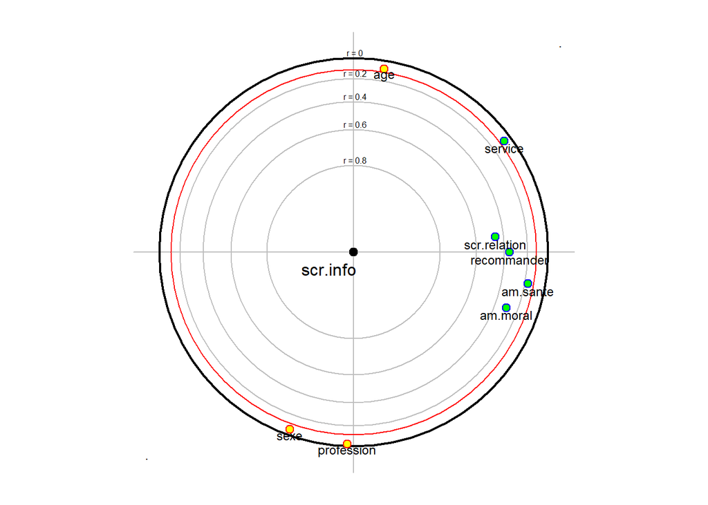

```r
library("psy")
expliquer<-"scr.info"
explicatives<-c("sexe","age","profession","am.sante","am.moral","service","scr.relation","recommander")
fpca(data=data, y=expliquer, x=explicatives, partial="No")
```

Nous observons un cercle : en son centre se trouve la variable à expliquer, ici la variable score.information (scr.info), relative à la qualité de l’information reçue par le patient lors de son séjour. Avec ce type d’analyse, nous pouvons interpréter de manière précise les relations existantes entre les variables explicatives et la variable à expliquer.

Par exemple, entre la variable amelioration.sante (am.sante) et la variable scr.info, la corrélation est égale à 0,2, car elle se situe sur le cercle correspondant à r=0,2.

On peut également dire que cette corrélation est statistiquement significative au seuil de 5 %, puisque la variable am.sante se trouve à l’intérieur du cercle rouge, qui correspond à la limite de significativité des corrélations à ce seuil.

Par ailleurs, la variable am.sante est représentée par un point vert, ce qui indique une corrélation positive avec scr.info. Si le point était de couleur orange, la corrélation serait alors négative.